# ISLR Ch. 6

Austin Pesina

4/1/2021

## Problem 2

For parts (a) through (c), indicate which of i. through iv. is correct. Justify your answer. *i. More flexible and hence will give improved prediction accuracy when it increase in bias is less than its decrease in variance*  
*ii. More flexible and hence will give improved prediction accuracy when its increase in variance is less than its decrease in bias.*  
*iii. Less flexible and hence will give improved prediction accuracy when its increase in bias is less than its decrease in variance.*  
*iv. Less flexible and hence will give improved prediction accuracy when its increase in variance is less than the decrease in bias.*

**(a) The lasso, relative to least squares, is:**

*iii. Less flexible and hence will give improved prediction accuracy when its increase in bias is less than its decrease in variance.*

Lasso’s advantage comes from the bias-variance trade-off. While a least squares estimate has high variance, the lasso reduces the variance in exchange for a small increase in bias.

**(b) Repeat (a) for ridge regression relative to least squares.**

*iii. Less flexible and hence will give improved prediction accuracy when its increase in bias is less than its decrease in variance.*

Like the lasso, ridge regression’s advantage also comes from the bias-variance trade-off. However, instead of comparing the least square estimate, ridge regression is a comparison between $\lambda$ and variance and bias.

**(c) Repeat (a) for non-linear methods relative to least squares.**

*ii. More flexible and hence will give improved prediction accuracy when its increase in variance is less than its decrease in bias.*

Non-linear methods are generally more flexible than least squares.

## Problem 9In this exercise, we will predict the number of application received using the other variables in the `College` data set.

**(a) Split the data set into a training set and a test set.**

```r
set.seed(1)
trainindex <- sample(nrow(College), 0.75*nrow(College))
head(trainindex)
```

```
## [1] 679 129 509 471 299 270
```

```r
train <- College[trainindex,]
test <- College[-trainindex,]
dim(College)
```

```
## [1] 777  18
```

```r
dim(train)
```

```
## [1] 582  18
```

```r
dim(test)
```

```
## [1] 195  18
```

**(b) Fit a linear model using least squares on the training set, and report the test error obtained.**

```r
lm.fit <- lm(Apps~., data=train)
summary(lm.fit)
```

```
##
## Call:
## lm(formula = Apps ~ ., data = train)
##
## Residuals:
##     Min      1Q  Median      3Q     Max
## -5773.1  -425.2     4.5   327.9  7496.3
##
## Coefficients:
##               Estimate Std. Error t value Pr(>|t|)
## (Intercept) -5.784e+02  4.707e+02  -1.229  0.21962
## PrivateYes  -4.673e+02  1.571e+02  -2.975  0.00305 **
## Accept       1.712e+00  4.567e-02  37.497  < 2e-16 ***
## Enroll      -1.197e+00  2.151e-01  -5.564 4.08e-08 ***
## Top10perc    5.298e+01  6.158e+00   8.603  < 2e-16 ***
## Top25perc   -1.528e+01  4.866e+00  -3.141  0.00177 **
## F.Undergrad  7.085e-02  3.760e-02   1.884  0.06002 .
## P.Undergrad  5.771e-02  3.530e-02   1.635  0.10266
## Outstate    -8.143e-02  2.077e-02  -3.920 9.95e-05 ***
## Room.Board   1.609e-01  5.361e-02   3.002  0.00280 **
## Books        2.338e-01  2.634e-01   0.887  0.37521
## Personal     6.611e-03  6.850e-02   0.097  0.92315
## PhD         -1.114e+01  5.149e+00  -2.163  0.03093 *
## Terminal     9.186e-01  5.709e+00   0.161  0.87223
## S.F.Ratio    1.689e+01  1.542e+01   1.096  0.27368
## perc.alumni  2.256e+00  4.635e+00   0.487  0.62667
## Expend       5.567e-02  1.300e-02   4.284 2.16e-05 ***
## Grad.Rate    6.427e+00  3.307e+00   1.944  0.05243 .
## ---
## Signif. codes:  0 '***' 0.001 '**' 0.01 '*' 0.05 '.' 0.1 ' ' 1
##
## Residual standard error: 1009 on 564 degrees of freedom
## Multiple R-squared:  0.9336, Adjusted R-squared:  0.9316
## F-statistic: 466.7 on 17 and 564 DF,  p-value: < 2.2e-16
```

```r
lm.pred <- predict(lm.fit, newdata=test)
lm.err <- mean((test$Apps-lm.pred)^2)
lm.err
```

```
## [1] 1384604
```

The test error from the model on all variables is 1384604 The $r^2$ is 93.36%, meaning that 93% of the variance is described by the model.

**(c) Fit a ridge regression model on the training set, with $\lambda$ chosen by cross-validation. Report the test error obtained, along with the number of non-zero coefficient estimates.**

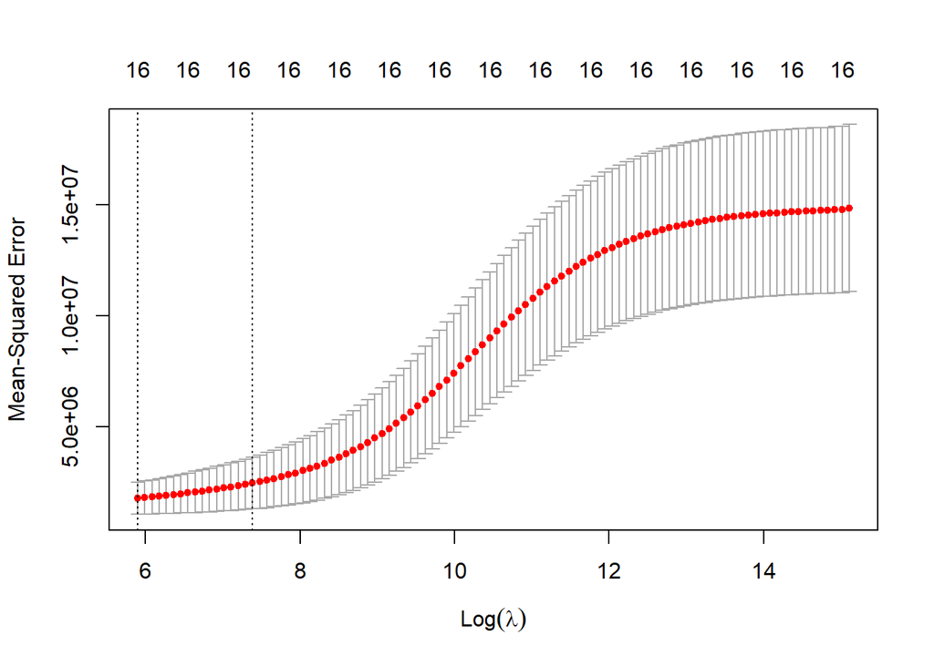

```r
xtrain <- model.matrix(Apps~., data=train[,-1])
ytrain <- train$Apps
xtest <- model.matrix(Apps~., data=test[,-1])
ytest <- test$Apps
ridge.fit <- cv.glmnet(xtrain,ytrain,alpha=0)
plot(ridge.fit)
```

```r
ridge.lambda <- ridge.fit$lambda.min
ridge.lambda
```

```
## [1] 364.6228
```

After comparing $\lambda$ and the MSE for ridge regression, we find the $\lambda$ that reduces the error is 364.62

```r
ridge.pred <- predict(ridge.fit, s=ridge.lambda, newx = xtest)
ridge.err <- mean((ridge.pred-ytest)^2)
ridge.err
```

```
## [1] 1260111
```

The ridge regression of 1260111 is a better test error than the OLS.

**(d) Fit a lasso model on the training set, with $\lambda$ chosen by cross-validation. Report the test error obtained, along with the number of non-zero coefficient estimates.**

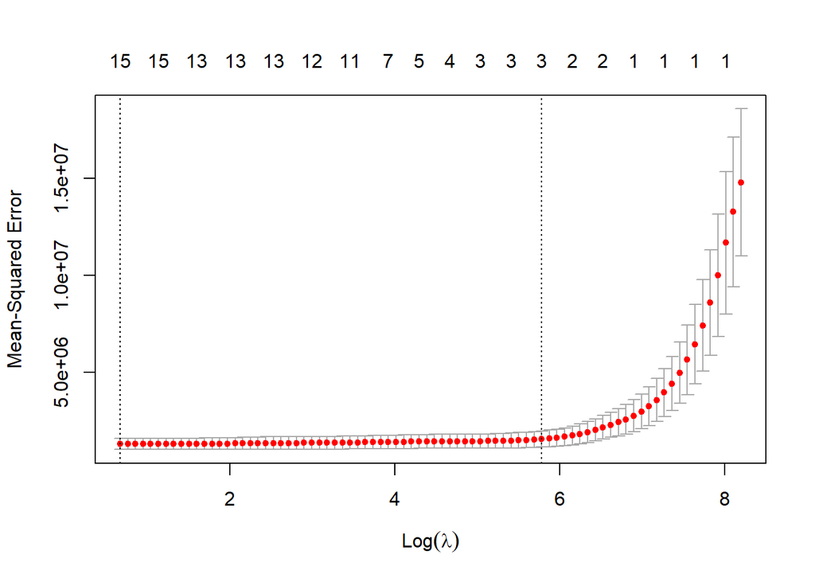

```r
lasso.fit <- cv.glmnet(xtrain, ytrain, alpha=1)
plot(lasso.fit)
```

```r
lasso.lambda <- lasso.fit$lambda.min
lasso.lambda
```

```
## [1] 1.945882
```

```r
lasso.pred <- predict(lasso.fit, s=lasso.lambda, newx= xtest)
lasso.err <- mean((lasso.pred-ytest)^2)
lasso.err
```

```
## [1] 1394834
```

```r
lasso.coef <- predict(lasso.fit, type="coefficients", s=lasso.lambda)[1:18,]
lasso.coef
```

```
##   (Intercept)   (Intercept)        Accept        Enroll     Top10perc
## -1.030320e+03  0.000000e+00  1.693638e+00 -1.100616e+00  5.104012e+01
##     Top25perc   F.Undergrad   P.Undergrad      Outstate    Room.Board
## -1.369969e+01  7.851307e-02  6.036558e-02 -9.861002e-02  1.475536e-01
##         Books      Personal           PhD      Terminal     S.F.Ratio
##  2.185146e-01  0.000000e+00 -8.390364e+00  1.349648e+00  2.457249e+01
##   perc.alumni        Expend     Grad.Rate
##  7.684156e-01  5.858007e-02  5.324356e+00
```

Lasso did not perform as well in prediction accuracy compared to the ridge regression. The variance in ridge regression was lower than lass, so it produces a smaller error.

**(e) Fit a PCR model on the training set, with $M$ chosen by cross-validation. Report the test error obtained, along with the value of $M$ selected by cross-validation.**

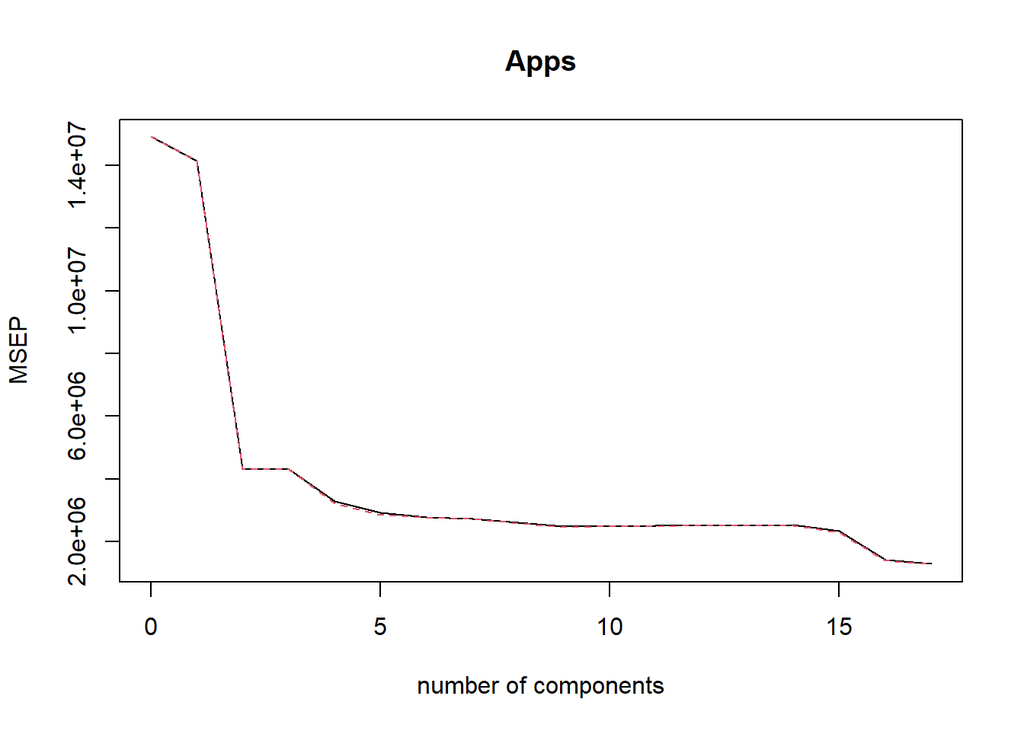

```r
pcr.fit <- pcr(Apps~., data=train, scale=T, validation="CV")
validationplot(pcr.fit, val.typ="MSEP")
```

```r
summary(pcr.fit)
```

```
## Data:    X dimension: 582 17
##  Y dimension: 582 1
## Fit method: svdpc
## Number of components considered: 17
##
## VALIDATION: RMSEP
## Cross-validated using 10 random segments.
##        (Intercept)  1 comps  2 comps  3 comps  4 comps  5 comps  6 comps
## CV            3862     3761     2078     2076     1809     1709     1662
## adjCV         3862     3761     2075     2076     1790     1689     1657
##        7 comps  8 comps  9 comps  10 comps  11 comps  12 comps  13 comps
## CV        1654     1615     1573      1578      1584      1587      1586
## adjCV     1649     1605     1568      1572      1579      1582      1580
##        14 comps  15 comps  16 comps  17 comps
## CV         1588      1528      1193      1133
## adjCV      1583      1511      1183      1124
##
## TRAINING: % variance explained
##       1 comps  2 comps  3 comps  4 comps  5 comps  6 comps  7 comps  8 comps
## X      32.159    57.17    64.41    70.20    75.53    80.48    84.24    87.56
## Apps    5.226    71.83    71.84    80.02    83.01    83.07    83.21    84.46
##       9 comps  10 comps  11 comps  12 comps  13 comps  14 comps  15 comps
## X       90.54     92.81     94.92     96.73     97.81     98.69     99.35
## Apps    85.00     85.22     85.22     85.23     85.36     85.45     89.93
##       16 comps  17 comps
## X        99.82    100.00
## Apps     92.84     93.36
```

Using cross-validation with the MSEP, the lowest MSE is at 17 components. 17 components has the lowest CV error and explains 100% of the variance in the predictors, and 93% of the variance in `Apps`.

```r
pcr.pred <- predict(pcr.fit, test, ncom=17)
pcr.err <- mean((pcr.pred-test$Apps)^2)
pcr.err
```

```
## [1] 1384604
```

**(f) Fit a PLS model on the training set, with $M$ chosen by cross-validation. Report the test error obtained, along with the value of $M$ selected by cross-validation.**

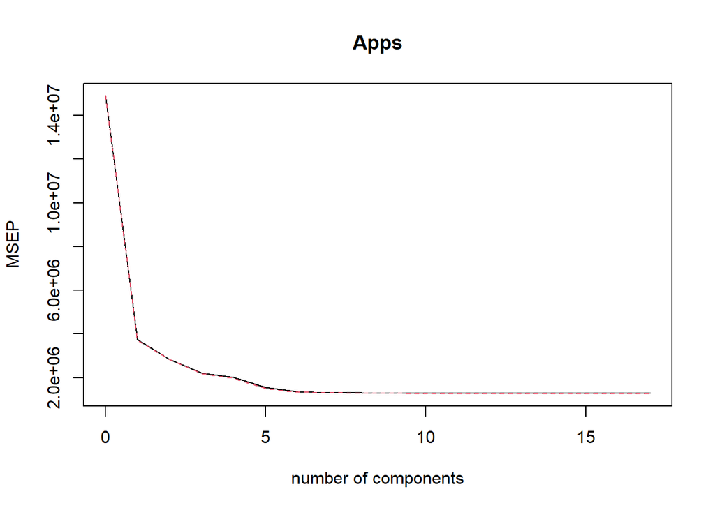

```r
pls.fit <- plsr(Apps~., data=train, scale=T, validation="CV")
validationplot(pls.fit, val.type = "MSEP")
```

```r
summary(pls.fit)
```

```
## Data:    X dimension: 582 17
##  Y dimension: 582 1
## Fit method: kernelpls
## Number of components considered: 17
##
## VALIDATION: RMSEP
## Cross-validated using 10 random segments.
##        (Intercept)  1 comps  2 comps  3 comps  4 comps  5 comps  6 comps
## CV            3862     1933     1688     1489     1424     1250     1167
## adjCV         3862     1927     1687     1482     1404     1227     1157
##        7 comps  8 comps  9 comps  10 comps  11 comps  12 comps  13 comps
## CV        1149     1144     1138      1134      1135      1132      1132
## adjCV     1140     1136     1130      1126      1127      1124      1123
##        14 comps  15 comps  16 comps  17 comps
## CV         1130      1131      1130      1130
## adjCV      1122      1122      1122      1122
##
## TRAINING: % variance explained
##       1 comps  2 comps  3 comps  4 comps  5 comps  6 comps  7 comps  8 comps
## X       25.67    47.09    62.54     65.0    67.54    72.28    76.80    80.63
## Apps    76.80    82.71    87.20     90.8    92.79    93.05    93.14    93.22
##       9 comps  10 comps  11 comps  12 comps  13 comps  14 comps  15 comps
## X       82.71     85.53     88.01     90.95     93.07     95.18     96.86
## Apps    93.30     93.32     93.34     93.35     93.36     93.36     93.36
##       16 comps  17 comps
## X        98.00    100.00
## Apps     93.36     93.36
```

With this validation plot, we see that the MSE begins to drop towards its lowest at around 5 components. At 9 components we begin to see very little increase in the amount of variance that the response variable explains.

```r
pls.pred <- predict(pls.fit, test, ncomp=9)
pls.err <- mean((pls.pred-test$Apps)^2)
pls.err
```

```
## [1] 1381335
```

**(g) Comment on the results obtained. How accurately can we predict the number of college applications received? Is there much difference among the test errors resulting from these five approaches?**

## Problem 11

We will now try to predict per capita crime rate in the `Boston` data set.

**(a) Try out some of the regression methods explored in this chapter, such as best subset selection, the lasso, ridge regression, and PCR. Present and discuss results for the approaches that you consider.**

### Best Subset Selection

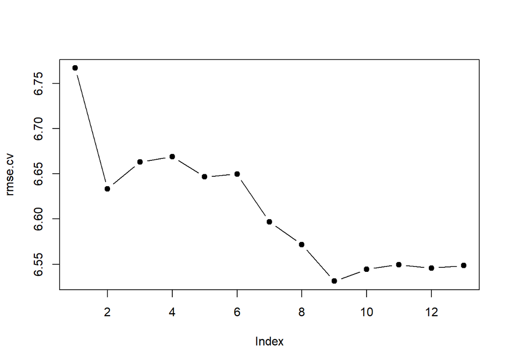

```r
predict.regsubsets <- function(object, newdata, id, ...) {
    form <- as.formula(object$call[[2]])
    mat <- model.matrix(form, newdata)
    coefi <- coef(object, id=id)
    mat[, names(coefi)] %*% coefi
}

k <- 10
p <- ncol(Boston) - 1
folds <- sample(rep(1:k, length = nrow(Boston)))

cv.errors <- matrix(NA,k,p)
for (i in 1:k) {
    best.fit <- regsubsets(crim ~ ., data = Boston[folds != i, ], nvmax = p)
    for (j in 1:p) {
          pred <- predict(best.fit, Boston[folds ==i,], id=j)
          cv.errors[i,j] <- mean((Boston$crim[folds == i]-pred)^2)
    }
                }

rmse.cv <- sqrt(apply(cv.errors, 2, mean))
plot(rmse.cv, pch=19, type = "b")
```

```r
summary(best.fit)
```

```
## Subset selection object
## Call: regsubsets.formula(crim ~ ., data = Boston[folds != i, ], nvmax = p)
## 13 Variables  (and intercept)
##         Forced in Forced out
## zn          FALSE      FALSE
## indus       FALSE      FALSE
## chas        FALSE      FALSE
## nox         FALSE      FALSE
## rm          FALSE      FALSE
## age         FALSE      FALSE
## dis         FALSE      FALSE
## rad         FALSE      FALSE
## tax         FALSE      FALSE
## ptratio     FALSE      FALSE
## black       FALSE      FALSE
## lstat       FALSE      FALSE
## medv        FALSE      FALSE
## 1 subsets of each size up to 13
## Selection Algorithm: exhaustive
##           zn  indus chas nox rm  age dis rad tax ptratio black lstat medv
## 1  ( 1 )  " " " "   " "  " " " " " " " " "*" " " " "     " "   " "   " "
## 2  ( 1 )  " " " "   " "  " " " " " " " " "*" " " " "     " "   "*"   " "
## 3  ( 1 )  " " " "   " "  " " " " " " " " "*" " " " "     "*"   "*"   " "
## 4  ( 1 )  "*" " "   " "  " " " " " " "*" "*" " " " "     " "   " "   "*"
## 5  ( 1 )  "*" " "   " "  " " " " " " "*" "*" " " " "     "*"   " "   "*"
## 6  ( 1 )  "*" "*"   " "  " " " " " " "*" "*" " " " "     "*"   " "   "*"
## 7  ( 1 )  "*" " "   " "  "*" " " " " "*" "*" " " "*"     "*"   " "   "*"
## 8  ( 1 )  "*" " "   " "  "*" " " " " "*" "*" " " "*"     "*"   "*"   "*"
## 9  ( 1 )  "*" "*"   " "  "*" " " " " "*" "*" " " "*"     "*"   "*"   "*"
## 10  ( 1 ) "*" "*"   " "  "*" "*" " " "*" "*" " " "*"     "*"   "*"   "*"
## 11  ( 1 ) "*" "*"   " "  "*" "*" " " "*" "*" "*" "*"     "*"   "*"   "*"
## 12  ( 1 ) "*" "*"   "*"  "*" "*" " " "*" "*" "*" "*"     "*"   "*"   "*"
## 13  ( 1 ) "*" "*"   "*"  "*" "*" "*" "*" "*" "*" "*"     "*"   "*"   "*"
```

```r
which.min(rmse.cv)
```

```
## [1] 9
```

```r
boston.bsm.err <- (rmse.cv[which.min(rmse.cv)]^2)
boston.bsm.err
```

```
## [1] 42.65854
```

## LASSO

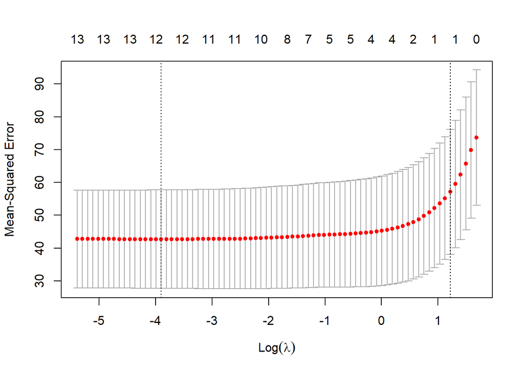

```r
boston.x <- model.matrix(crim~., data = Boston)[,-1]
boston.y <- Boston$crim
boston.lasso <- cv.glmnet(boston.x,boston.y,alpha=1, type.measure ="mse")
plot(boston.lasso)
```

```r
coef(boston.lasso)
```

```
## 14 x 1 sparse Matrix of class "dgCMatrix"
##                     1
## (Intercept) 1.4186415
## zn          .
## indus       .
## chas        .
## nox         .
## rm          .
## age         .
## dis         .
## rad         0.2298449
## tax         .
## ptratio     .
## black       .
## lstat       .
## medv        .
```

```r
boston.lasso.err <- (boston.lasso$cvm[boston.lasso$lambda==boston.lasso$lambda.1se])
boston.lasso.err
```

```
## [1] 57.1608
```

Lasso is a variable reduction model. The MSE only keeps 1 variable, rad, and has an MSE of 57.1.

### Ridge Regression

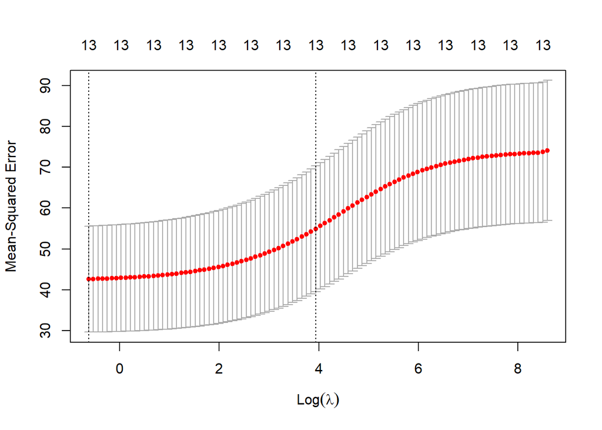

```r
boston.ridge <- cv.glmnet(boston.x,boston.y, type.measure="mse", alpha=0)
plot(boston.ridge)
```

```r
coef(boston.ridge)
```

```
## 14 x 1 sparse Matrix of class "dgCMatrix"
##                        1
## (Intercept)  0.887549642
## zn          -0.002684451
## indus        0.035521503
## chas        -0.242070223
## nox          2.338520332
## rm          -0.166158479
## age          0.007601568
## dis         -0.120012848
## rad          0.063692316
## tax          0.002813534
## ptratio      0.090098298
## black       -0.003542339
## lstat        0.046779459
## medv        -0.030585796
```

```r
boston.ridge.err <- boston.ridge$cvm[boston.ridge$lambda==boston.ridge$lambda.1se]
boston.ridge.err
```

```
## [1] 54.92844
```

### PCR

```r
boston.pcr <- pcr(crim~., data=Boston, scale=T, valdiation="CV")
summary(boston.pcr)
```

```
## Data:    X dimension: 506 13
##  Y dimension: 506 1
## Fit method: svdpc
## Number of components considered: 13
## TRAINING: % variance explained
##       1 comps  2 comps  3 comps  4 comps  5 comps  6 comps  7 comps  8 comps
## X       47.70    60.36    69.67    76.45    82.99    88.00    91.14    93.45
## crim    30.69    30.87    39.27    39.61    39.61    39.86    40.14    42.47
##       9 comps  10 comps  11 comps  12 comps  13 comps
## X       95.40     97.04     98.46     99.52     100.0
## crim    42.55     42.78     43.04     44.13      45.4
```

An appropriate PCR would contain 9 components. With 9 components, 95.4% of the variance with explained by the components in the model and 42.5% is explained in the response variable

**(b) Propose a model (or set of models) that seem to perform well on this data set, and justify your answer. Make sure that you are evaluating model performance using validation set error, cross-validation, or some other reasonable alternative, as opposed to using training error.**

**(c) Does your chosen model involve all of the features in the data set? WHy or why not?**

The best subset model only used 9 variables: zn, indus, nox, dis, rad, ptratio, black, lstat, and medv. If we included the rest of the variables, there would be more variation. We are looking to predict accuracy with low variance and low MSE, so we did not use those variables.